# HW1 Visualization. The Class Survey Data Visualization.

The Internet Explorers

## Introduction

This study analyzes the data from the initial survey conducted at the beginning of the course “Exploratory Data Analysis and Visualization” at Columbia University. The purpose of the first project, as the team members agreed, is to do some hands-on work with the visualization tools introduced in lecture. We will present, with original visualizations, answers to some questions about the data. To draw some of the charts, we copied the format from [fivethirtyeight.com](http://fivethirtyeight.com/), which is a great data-analysis and visualization site that we took as inspiration. Also, the colors used in the charts are the same as those used in the Google docs. This could be easily implemented using the package [ggthems](https://cran.r-project.org/web/packages/ggthemes/vignettes/ggthemes.html) as a complement of [ggplot2](http://ggplot2.org/). We strongly recomend that the reader take a look at these to avoid manually changing the font, the sizes, the colors, etc… in each graph individually in your future presentations.

## Who we are

In order to have a better understanding of the makeup of survey responders, an interactive visual graph was developed using d3 to show the the gender distribution among our various programs. Clearly, the number of male students (71%) is more than female (28%). Moreover, male students dominate the population for each program. It is worth mentioning that the highest percentage of female students is within the Masters in Statistics program, with around 47%. On the other hand, female students have the lowest percentage in the Data Science Program (both for Masters and Certification). Overall, the percentages can be summarized in a symmetric graph as follows. An interesting interactive chart can be found [here](http://aa3775.neocities.org/edav.html).

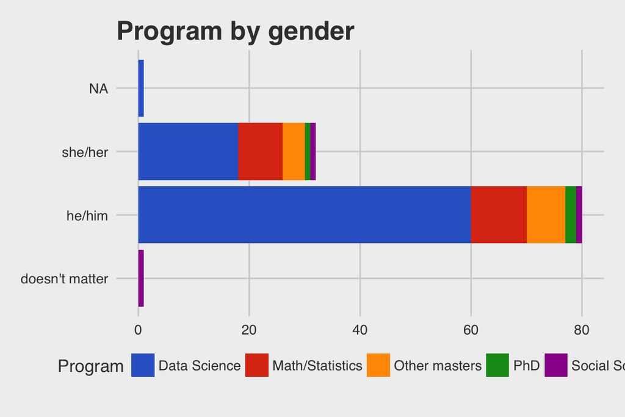

## How old are we?

The histogram of frequencies, shown in Figure 1 below, indicates that the male students seem to be, on average, approximately 5 years older than the females. The mean age values by gender, 27.6 for females and 32.7 for males, is traced with a vertical dotted line.

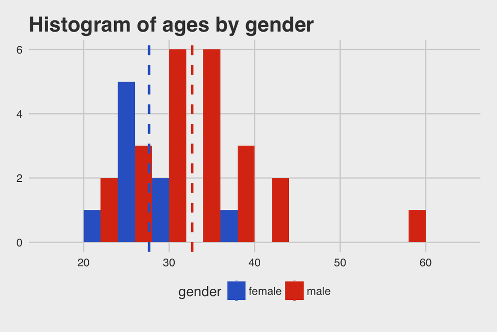

## Familiarity with Computational Tools

In this section we explore methods to visualize the relative knowledge of the class as far as computational tools are concerned. In the survey, students were asked to select which tools they felt comfortable using from among a list of 20. The type of tools varies from specific computer languages like Python, to more general applications like Google Drive.

We present two methods for visualizing which tools the greatest number of students feel comfortable with. The first is a Word Cloud. The Word Cloud below prints words with a font size that is correlated to the frequency of responses. So, for example, if more students selected ‘R’ than any other tool, then ‘R’ would show up in the largest font. To obtain this graph we used the package [wordcloud](https://cran.r-project.org/web/packages/wordcloud/wordcloud.pdf).

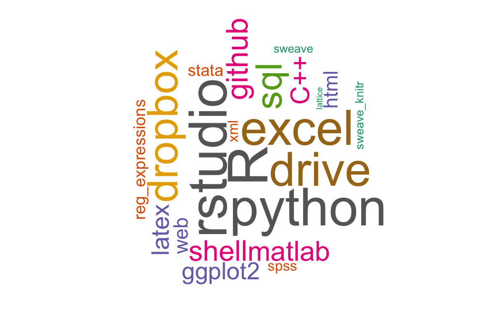

The Word Cloud, while not quantitative, provides a nice visual to give the audience a general sense of which tools are most well known among the class. We see that ‘R’ and ‘Python’ show up frequently, as well as ‘Excel’ and ‘Drive’. We were not surprised by this result, since these languages and tools are commonly pushed in our classes.

For a more quantitative visualization of the responses, we also present a histogram which is ordered from largest number of responses to smallest. From this we can see more accurately than with the Word Cloud which tools were responded to more frequently than others.

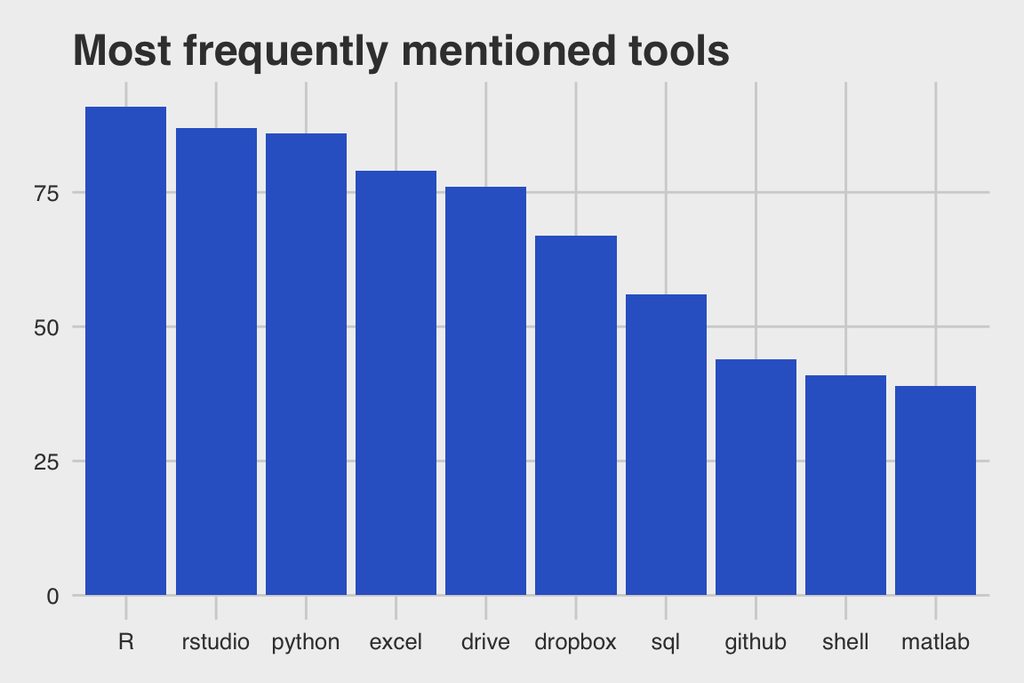

## What else do we know?

To explore the data about programming expreience and skill we show a bar chart and a series of bubble plots.

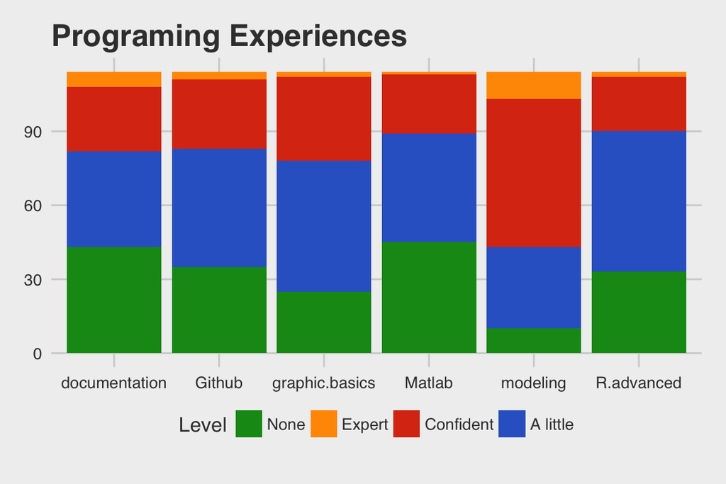

These folowing plot show the distribution of programming level among different skill levels.From the bubble chart, we can find that few people consider themselves as an expert in a specific field. More people have none experience in Matlab when compared to other fields.We can also find that people have more experience and are more proficient in modeling when compared to other fields.

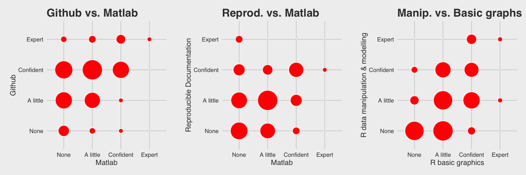

This is the end of our presentation. We hope you have taken something useful from it.